# 6 Feedforward Neural Networks

**Key references**

- **Universal approximation** — a feedforward network with a single hidden layer can approximate any continuous function to arbitrary accuracy, given enough neurons (Cybenko, 1989; Hornik et al., 1989).
- **Backpropagation** — the training algorithm that made multilayer networks practical (Rumelhart et al., 1986).
- **Deep learning review** — comprehensive overview of feedforward and deep architectures (LeCun et al., 2015).

The **feedforward neural network** (FNN), also called a **multilayer perceptron** (MLP), is the most fundamental neural network architecture. Data flows in one direction — from input to output — with no loops or recurrence.

## 6.1 Architecture

An FNN consists of:

1. An **input layer** — one node per feature (not a computation layer, just the data entry point).
2. One or more **hidden layers** — dense layers with activation functions.
3. An **output layer** — produces the final prediction.

Every neuron in one layer is connected to every neuron in the next layer, which is why these are called **fully connected** or **dense** layers.

For an FNN with $L$ hidden layers, the computation at each layer $l$ is:

$$\mathbf{h}^{(l)} = \sigma\!\bigl(W^{(l)}\,\mathbf{h}^{(l-1)} + \mathbf{b}^{(l)}\bigr)$$

where $\mathbf{h}^{(0)} = \mathbf{x}$ is the input and $\hat{\mathbf{y}} = \mathbf{h}^{(L+1)}$ is the output.

## 6.2 Universal approximation

The **universal approximation theorem** (Cybenko, 1989; Hornik et al., 1989) states that a feedforward network with a single hidden layer containing a sufficient number of neurons can approximate any continuous function on a compact set to arbitrary precision. This is a powerful existence result, but it does not tell you *how many* neurons you need or *how* to find the weights. In practice, deeper (more layers) but narrower networks tend to generalize better than a single massive hidden layer.

## 6.3 Code example: function approximation

Let’s use a feedforward network to approximate the function $f(x) = \sin(2\pi x)\, e^{-x^2}$ from noisy samples.

```julia
using Lux, Random, Optimisers, Zygote, Statistics, Printf, CairoMakie

rng = Xoshiro(42)

# Generate training data
n = 200
x_data = Float32.(range(-2, 2, length = n))
f_true(x) = sin(2π * x) * exp(-x^2)
y_data = f_true.(x_data) .+ 0.05f0 .* randn(rng, Float32, n)

X = reshape(x_data, 1, :)
Y = reshape(y_data, 1, :)
```

[output not shown]

```julia
# Build a 2-hidden-layer FNN
model = Chain(
    Dense(1 => 32, relu),
    Dense(32 => 32, relu),
    Dense(32 => 1)
)

ps, st = Lux.setup(rng, model)

function mse_loss(model, ps, st, data)
    x, y = data
    ŷ, st_new = model(x, ps, st)
    loss = mean((ŷ .- y) .^ 2)
    return loss, st_new, ()
end
```

```
mse_loss (generic function with 1 method)
```

```julia
opt = Adam(0.005f0)
tstate = Training.TrainState(model, ps, st, opt)

for epoch in 1:1000
    _, loss, _, tstate = Training.single_train_step!(
        AutoZygote(), mse_loss, (X, Y), tstate
    )
    if epoch == 1 || epoch % 200 == 0
        @printf "Epoch %4d  MSE = %.6f\n" epoch loss
    end
end
```

```
Epoch    1  MSE = 3.924546
Epoch  200  MSE = 0.029474
Epoch  400  MSE = 0.026527
Epoch  600  MSE = 0.021628
Epoch  800  MSE = 0.017864
Epoch 1000  MSE = 0.016793
```

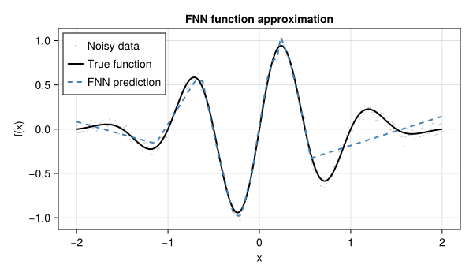

```julia
# Plot the result
x_fine = Float32.(range(-2, 2, length = 500))
X_fine = reshape(x_fine, 1, :)
Y_pred, _ = model(X_fine, tstate.parameters, tstate.states)

fig = Figure(size = (600, 350))
ax = Axis(fig[1, 1], xlabel = "x", ylabel = "f(x)",
          title = "FNN function approximation")
scatter!(ax, x_data, y_data, markersize = 3, color = (:gray, 0.4),
         label = "Noisy data")
lines!(ax, x_fine, f_true.(x_fine), color = :black, linewidth = 2,
       label = "True function")
lines!(ax, x_fine, vec(Y_pred), color = :steelblue, linewidth = 2,
       linestyle = :dash, label = "FNN prediction")
axislegend(ax, position = :lt)
fig
```

## 6.4 Effect of depth and width

The universal approximation theorem guarantees that a *wide enough* single hidden layer can approximate any function. In practice:

- **Wider** layers (more neurons) increase capacity but can overfit.
- **Deeper** networks (more layers) learn hierarchical features and often generalize better with fewer total parameters.
- **Very deep** networks are harder to train due to vanishing gradients — residual connections (He et al., 2016) and normalization help.

A useful rule of thumb: start with 2–3 hidden layers of moderate width (32–128 neurons) and adjust based on performance.

## 6.5 When to use feedforward networks

FNNs are the default starting point whenever:

- The input is a **fixed-size feature vector** (e.g., geophysical measurements at a station).
- There is **no spatial or temporal structure** that you want the architecture to exploit.
- You need a **simple, fast, interpretable baseline** before trying more complex architectures.

For data with spatial structure (images, grids), convolutional networks are usually better. For sequential data (time series), recurrent networks or transformers are preferred. The FNN remains the building block inside most of these architectures.

## 6.6 Geoscience applications

Feedforward networks have been widely used in geoscience as flexible function approximators:

- **Geophysical inversion** — FNNs serve as surrogate forward models, mapping model parameters to predicted data. Once trained, they replace expensive physics-based simulations and can be embedded inside iterative inversion schemes (Lopez-Alvis et al., 2019).
- **Rock physics** — predicting physical properties (porosity, permeability, velocity) from well-log or laboratory measurements is a classic regression task well-suited to FNNs.
- **Geochemical classification** — mapping geochemical assay vectors to rock types or alteration classes.
- **Overview** — Bergen et al. (2019) and Reichstein et al. (2019) provide comprehensive reviews of machine learning applications across the geosciences, with many examples of FNN-based approaches for regression and classification in Earth science.

The FNN is rarely the final architecture for production geoscience workflows, but it is almost always the first model you should try. If an FNN solves the problem, the extra complexity of deeper architectures is unnecessary.

Bergen, K. J., Johnson, P. A., Hoop, M. V. de, & Beroza, G. C. (2019). Machine learning for data-driven discovery in solid earth geoscience. *Science*, *363*(6433). https://doi.org/10.1126/science.aau0323

Cybenko, G. (1989). Approximation by superpositions of a sigmoidal function. *Mathematics of Control, Signals and Systems*, *2*(4), 303–314. https://doi.org/10.1007/BF02551274

He, K., Zhang, X., Ren, S., & Sun, J. (2016). Deep residual learning for image recognition. *Proceedings of the IEEE Conference on Computer Vision and Pattern Recognition (CVPR)*, 770–778. https://doi.org/10.1109/CVPR.2016.90

Hornik, K., Stinchcombe, M., & White, H. (1989). Multilayer feedforward networks are universal approximators. *Neural Networks*, *2*(5), 359–366. https://doi.org/10.1016/0893-6080(89)90020-8

LeCun, Y., Bengio, Y., & Hinton, G. (2015). Deep learning. *Nature*, *521*, 436–444. https://doi.org/10.1038/nature14539

Lopez-Alvis, J., Hermans, T., Nguyen, F., Caterina, D., & Haugerud, A. J. (2019). Deep-learning-based inverse modeling approaches: A subsurface transport example. *Water Resources Research*, *55*(8), 6305–6327. https://doi.org/10.1029/2018WR024638

Reichstein, M., Camps-Valls, G., Stevens, B., Jung, M., Denzler, J., Carvalhais, N., & Prabhat. (2019). Deep learning and process understanding for data-driven earth system science. *Nature*, *566*, 195–204. https://doi.org/10.1038/s41586-019-0912-1

Rumelhart, D. E., Hinton, G. E., & Williams, R. J. (1986). Learning representations by back-propagating errors. *Nature*, *323*, 533–536. https://doi.org/10.1038/323533a0